# 07-mle-and-mm

Kelly Chen

11/6/2021

```r
library(stats4)
library(dplyr)
Hmisc::getHdata(nhgh)
d1 <- nhgh %>%
  filter(sex == "female") %>%
  filter(age >= 18) %>%
  select(gh, ht) %>%
  filter(1:n()<=1000)
```

## Introduction

This is a tutorial in which I will explain how one might use MLE and MM to model Glycohemoglobin and Height of adult females. The data is from National Health and Nutrition Examination Survey 2009-2010 (NHANES), available from the Hmisc package. I will compare and contrast the two methods in addition to comparing and contrasting the choice of underlying distribution.

**MLE(Maximum Likelihood Estimation)**: A method of estimating the parameters of an assumed probability distribution, given some observed data. This is achieved by maximizing a likelihood function so that, under the assumed statistical model, the observed data is most probable.

**MM(Method of Moments)**: A method of estimation of population parameters. It starts by expressing the population moments as functions of the parameters of interest. Those expressions are then set equal to the sample moments.

## Method of Moments (Variable: Glycohemoglobin(gh))

## Estimates of parameters

For the estimation of parameters, we would take the sampling distribution way to calculate the sample parameters of the distribution that we need.

# Normal Distribution

```r
mm_norm_mean<-mean(d1$gh)
mm_norm_sd<-sd(d1$gh)
mm_norm_mean
```

```
## [1] 5.7246
```

```r
mm_norm_sd
```

```
## [1] 1.052246
```

For the normal distribution, the sample mean would be the mean of population and the sample standard deviation is also the sd of population.

# Gamma Distribution

```r
mm_gm_shape<-(mean(d1$gh))**2/var(d1$gh)
mm_gm_scale=var(d1$gh)/mean(d1$gh)
mm_gm_shape
```

```
## [1] 29.59754
```

```r
mm_gm_scale
```

```
## [1] 0.1934147
```

In Gamma distribution, the estimated shape parameter is 29.59754 and the estimated scale parameter is 0.1934147.

# Weibull Distribution

```r
wei_mean<-function(lambda,k){
  lambda*gamma(1+1/k)
}

lambda<-function(mean_bar,k){
  mean_bar/gamma(1+1/k)
}
wei_variance<-function(mean_bar,k,var_bar){
  (lambda(mean_bar,k)^2)*((gamma(1+2/k))-(gamma(1+1/k))^2)-var_bar
}

wei_k<-optimize(function(x){abs(wei_variance(mean_bar=mean(d1$gh),k=x,var_bar = var(d1$gh)))},lower = 0,upper = 50)
wei_k<-wei_k$minimum
wei_lambda<-lambda(mean(d1$gh),wei_k)

wei_k
```

```
## [1] 6.353163
```

```r
wei_lambda
```

```
## [1] 6.151309
```

## Overlay estimated pdf onto histogram

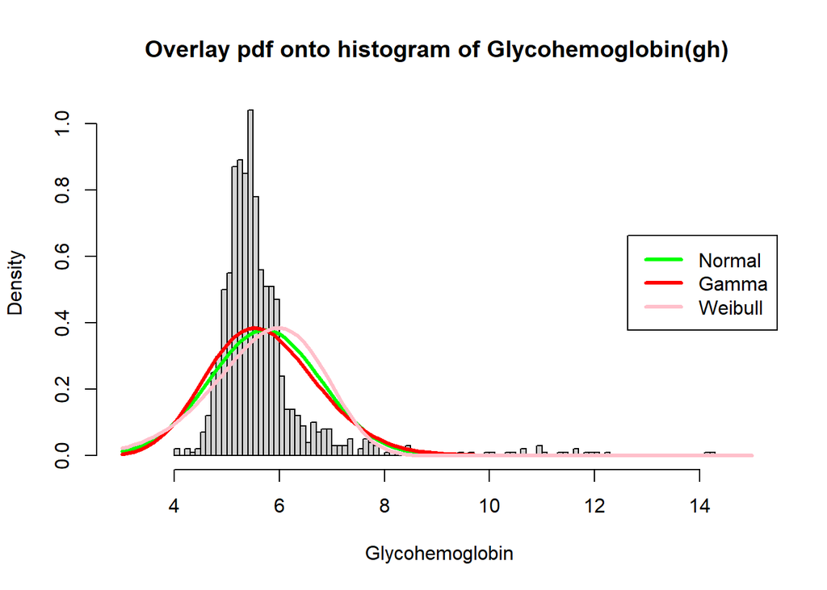

```r
hist(d1$gh,main="Overlay pdf onto histogram of Glycohemoglobin(gh)",xlab=" Glycohemoglobin",breaks = 100,freq = FALSE,xlim = c(3,15))

# Normal Distribution
curve(dnorm(x,mm_norm_mean,mm_norm_sd),add = TRUE,col="green",lwd=3)

# Gamma Distribution
curve(dgamma(x,shape=mm_gm_shape,scale=mm_gm_scale),add=TRUE,col="red",lwd=3)

#Weibull Distribution
curve(dweibull(x,shape=wei_k,scale=wei_lambda),add=TRUE,col="pink",lwd=3)

legend(x="right",legend=c("Normal","Gamma","Weibull"),lty=c(1,1,1),col=c("green","red","pink"),lwd=3)
```

## Overlay estimated CDF onto eCDF

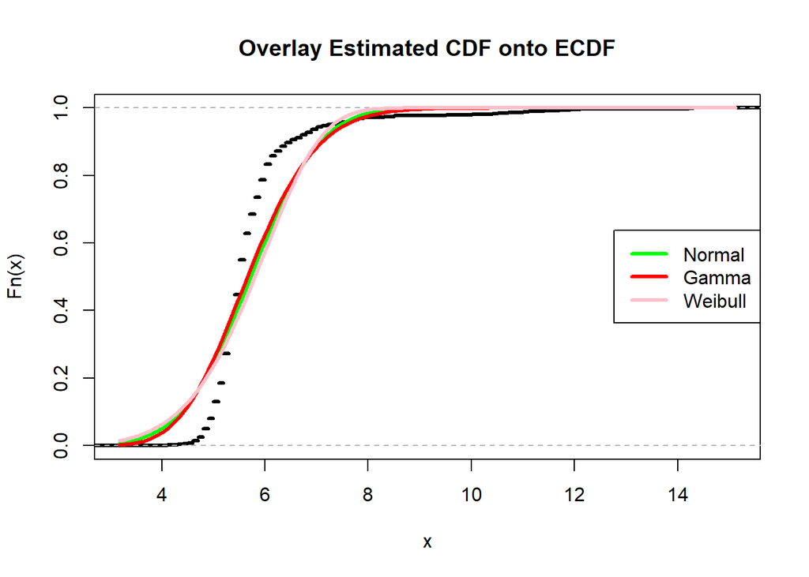

```r
plot(ecdf(d1$gh),do.points=FALSE,lwd=3,main="Overlay Estimated CDF onto ECDF")
# Normal Distribution
curve(pnorm(x,mm_norm_mean,mm_norm_sd),add = TRUE,col="green",lwd=3)

# Gamma Distribution
curve(pgamma(x,shape=mm_gm_shape,scale=mm_gm_scale),add=TRUE,col="red",lwd=3)

#Weibull Distribution
curve(pweibull(x,shape=wei_k,scale=wei_lambda),add=TRUE,col="pink",lwd=3)

legend(x="right",legend=c("Normal","Gamma","Weibull"),lty=c(1,1,1),col=c("green","red","pink"),lwd=3)
```

From the plot, we can see that the estimated CDF of the three distributions are a little deviated from the ECDF of the original data.

## QQ plot(sample vs estimated dist)

For the qqplot, we generate 5000 probability points to get the sample distribution.

```r
sample_p<-ppoints(5000)
y<-quantile(d1$gh,probs = sample_p)
```

# Normal distribution

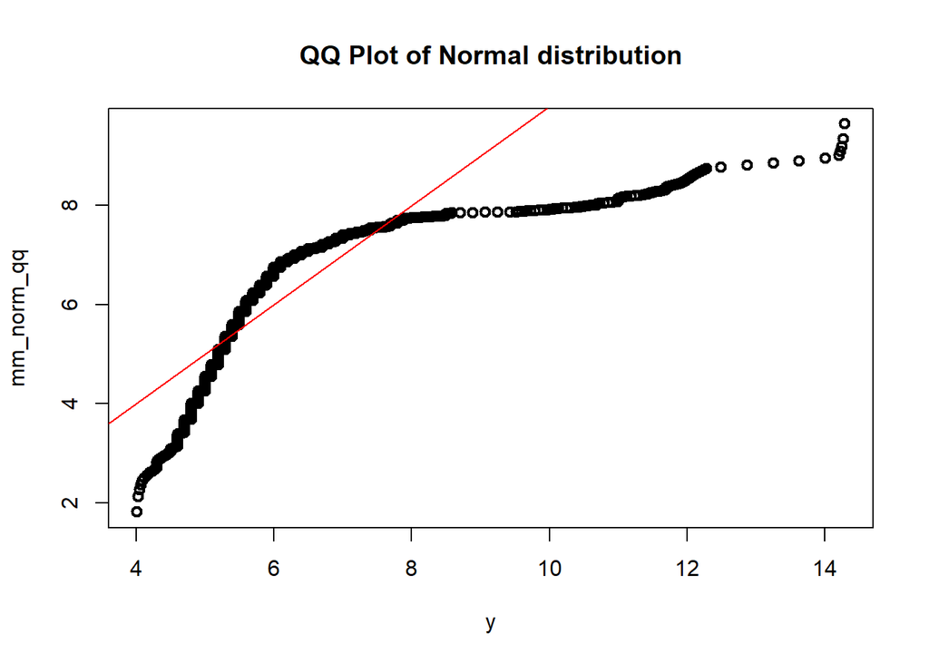

```r
mm_norm_qq<-qnorm(sample_p,mean=mm_norm_mean,sd=mm_norm_sd)
plot(y,mm_norm_qq,main="QQ Plot of Normal distribution",lwd=2)
abline(0,1,col="red")
```

This is the qq plot of normal distribution under method of moments, and we can see the sample quantile is deviated from the original quantile function at some extent.

# Gamma Distribution

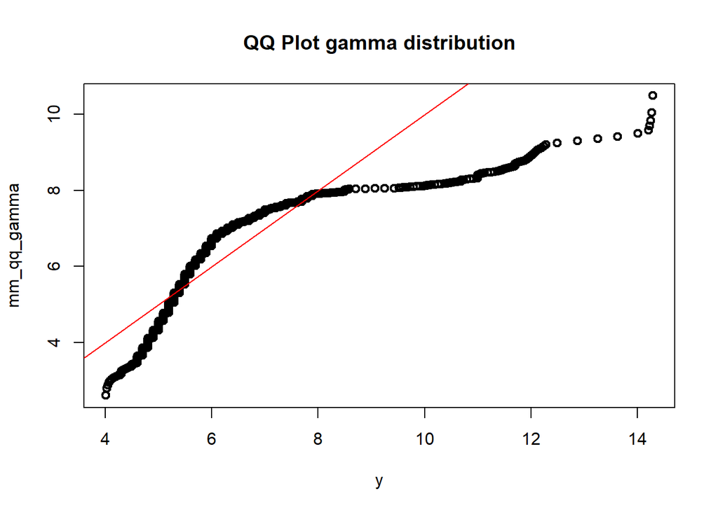

```r
mm_qq_gamma<-qgamma(sample_p,shape=mm_gm_shape,scale=mm_gm_scale)
plot(y,mm_qq_gamma,main="QQ Plot gamma distribution",lwd=2)
abline(a=0,b=1,col="red")
```

This is the qq plot of gamma distribution under method of moments, and we can see the sample quantile is deviated from the original quantile function at some extent.

# Weibull Distribution

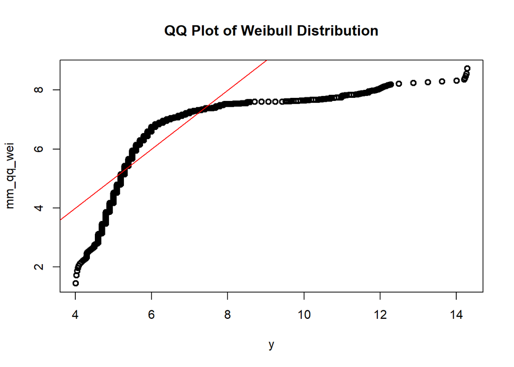

```r
mm_qq_wei<-qweibull(sample_p,shape=wei_k,scale=wei_lambda)
plot(y,mm_qq_wei,main="QQ Plot of Weibull Distribution",lwd=2)
abline(0,1,col="red")
```

This is the qq plot of Weibull distribution under method of moments, and we can see the sample quantile is deviated from the original quantile function at some extent.

## Estimate Median

# Normal Distribution

For the normal distribution, the sample median is equal to the population median, so we can just take the median of the data and calculate the result.

```r
median(d1$gh)
```

```
## [1] 5.5
```

As we can see, the estimated median under methods of moments with Normal distribution is 5.5.

# Gamma Distribution

For the gamma distribution, we can use qgamma to get the 50 percentile which is the estimated median, so we can just take the 50 percentile of the data and calculate the result.

```r
qgamma(0.5,shape=mm_gm_shape,scale=mm_gm_scale)
```

```
## [1] 5.660259
```

As we can see, the estimated median under methods of moments with Gamma distribution is 5.660259.

# Weibull Distribution

For the Weibull distribution, we can use qweibull to get the 50 percentile which is the estimated median, so we can just take the 50 percentile of the data and calculate the result.

```r
qweibull(0.5,shape = wei_k,scale=wei_lambda)
```

```
## [1] 5.806483
```

As we can see, the estimated median under methods of moments with Weibull distribution is 5.806483.

## Maximum Likelihood Estimation (Variable: Glycohemoglobin(gh))

Now let us take a look at how sampling distribution fits under the maximum likelihood estimation.

## Estimates of parameters

For the estimation of parameters, we would estimate the unknown parameter that maximizes the log likelihood.

# Normal Distribution

```r
require(stats4)
nLL_norm<-function(mean,sd){
  fs<-dnorm(x=d1$gh,mean=mean,sd=sd,log=TRUE)
  -sum(fs)
}
fit_norm<-mle(nLL_norm,start = list(mean=1,sd=1),method="L-BFGS-B",lower = c(0,0.01))
fit_norm
```

```
##
## Call:
## mle(minuslogl = nLL_norm, start = list(mean = 1, sd = 1), method = "L-BFGS-B",
##     lower = c(0, 0.01))
##
## Coefficients:
##    mean      sd
## 5.72460 1.05172
```

From the mle method in normal distribution, our estimated parameters are mean (5.72460), standard deviation(1.05172)

# Gamma Distribution

```r
nLL_gamma<-function(shape,scale){
  fs<-dgamma(x=d1$gh,shape=shape,scale=scale,log=TRUE)
  -sum(fs)
}
fit_gamma<-mle(nLL_gamma,start = list(shape=1,scale=1),method="L-BFGS-B",lower = c(0,0.01))
fit_gamma
```

```
##
## Call:
## mle(minuslogl = nLL_gamma, start = list(shape = 1, scale = 1),
##     method = "L-BFGS-B", lower = c(0, 0.01))
##
## Coefficients:
##      shape      scale
## 40.7065048  0.1406358
```

From the mle method in gamma distribution, our estimated parameters are shape (40.7065048), scale(0.1406358 )

# Weibull Distribution

```r
nLL_wei<-function(shape,scale){
  fs<-dweibull(x=d1$gh,shape=shape,scale=scale,log=TRUE)
  -sum(fs)
}
fit_wei<-mle(nLL_wei,start = list(shape=1,scale=1),method="L-BFGS-B",lower = c(0,0.01))
fit_wei
```

```
##
## Call:
## mle(minuslogl = nLL_wei, start = list(shape = 1, scale = 1),
##     method = "L-BFGS-B", lower = c(0, 0.01))
##
## Coefficients:
##    shape    scale
## 4.125254 6.173885
```

From the mle method in weibull distribution, our estimated parameters are shape (4.125254), scale(6.173885)

## Overlay estimated pdf onto histogram

# Normal Distribution

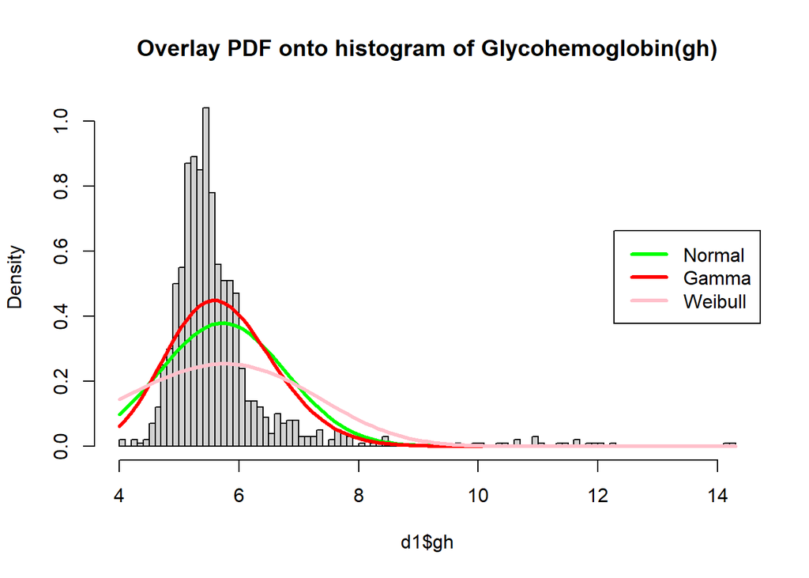

```r
hist(d1$gh,breaks = 100,main="Overlay PDF onto histogram of Glycohemoglobin(gh)",freq=FALSE)

#Normal Distribution
curve(dnorm(x,coef(fit_norm)[1],coef(fit_norm)[2]),add=TRUE,col="green",lwd=3)

#Gamma Distribution
curve(dgamma(x,shape=coef(fit_gamma)[1],scale=coef(fit_gamma)[2]),add=TRUE,col="red",lwd=3)

#Weibull Distribution
curve(dweibull(x,shape=coef(fit_wei)[1],scale=coef(fit_wei)[2]),add=TRUE,col="pink",lwd=3)

legend(x="right",legend=c("Normal","Gamma","Weibull"),lty=c(1,1,1),col=c("green","red","pink"),lwd=3)
```

## Overlay estimated CDF onto eCDF

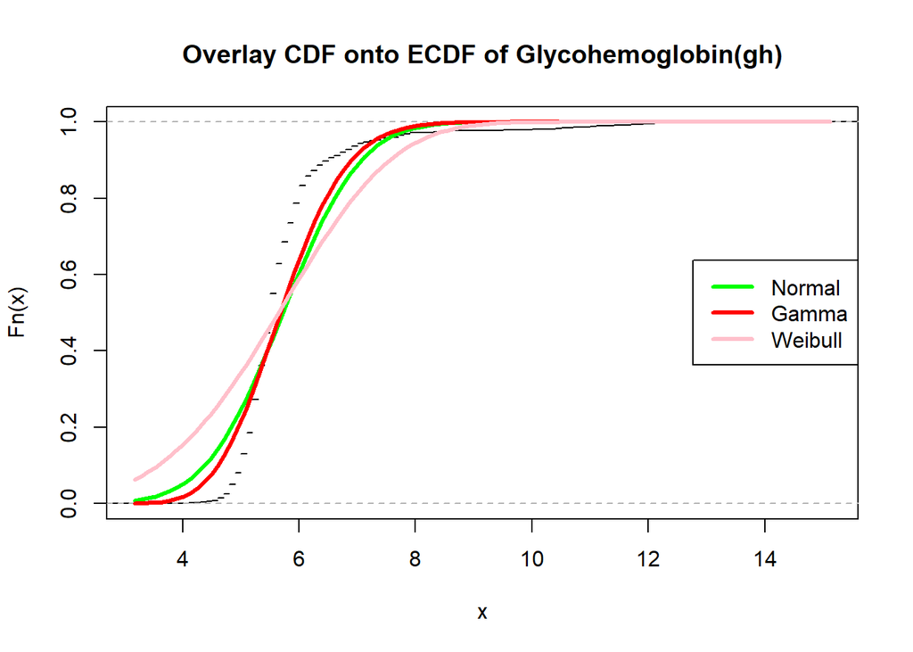

```r
plot(ecdf(d1$gh),main="Overlay CDF onto ECDF of Glycohemoglobin(gh)",do.points=FALSE)

#Normal Distribution
curve(pnorm(x,coef(fit_norm)[1],coef(fit_norm)[2]),add=TRUE,col="green",lwd=3)

#Gamma Distribution
curve(pgamma(x,shape=coef(fit_gamma)[1],scale=coef(fit_gamma)[2]),add=TRUE,col="red",lwd=3)

#Weibull Distribution
curve(pweibull(x,shape=coef(fit_wei)[1],scale=coef(fit_wei)[2]),add=TRUE,col="pink",lwd=3)

legend(x="right",legend=c("Normal","Gamma","Weibull"),lty=c(1,1,1),col=c("green","red","pink"),lwd=3)
```

## QQ plot(sample vs estimated dist)

```r
# Default
rand<-seq(0.01,0.99,by=0.001)
sample<-quantile(d1$gh,rand)
```

# Normal distribution

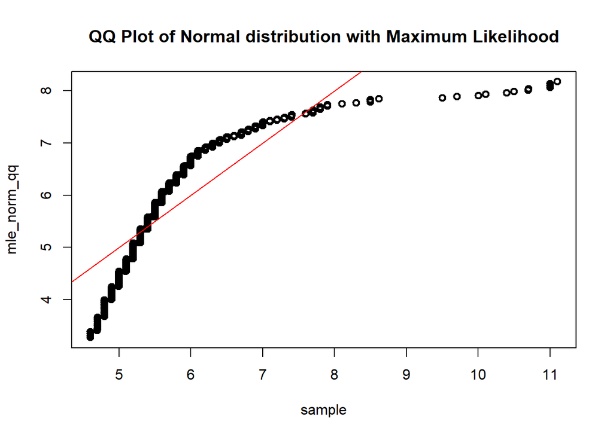

```r
mle_norm_qq<-qnorm(rand,mean=coef(fit_norm)[1],sd=coef(fit_norm)[2])
plot(sample,mle_norm_qq,main="QQ Plot of Normal distribution with Maximum Likelihood",lwd=2)
abline(0,1,col="red",asp=1)
```

This is the qq plot of Normal distribution under maximum likelihood, and we can see the sample quantile is deviated from the original quantile function at some extent.

# Gamma Distribution

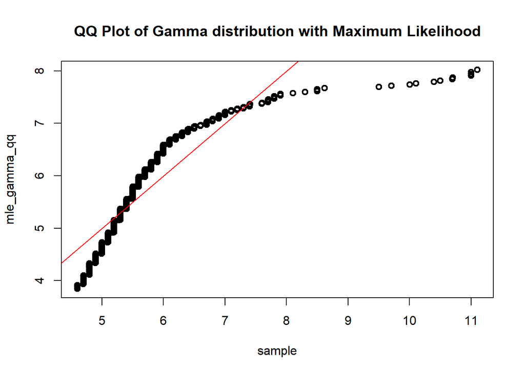

```r
mle_gamma_qq<-qgamma(rand,shape=coef(fit_gamma)[1],scale=coef(fit_gamma)[2])
plot(sample,mle_gamma_qq,main="QQ Plot of Gamma distribution with Maximum Likelihood",lwd=2)
abline(0,1,col="red",asp=1)
```

This is the qq plot of Gamma distribution under maximum likelihood, and we can see the sample quantile is deviated from the original quantile function at some extent.

# Weibull Distribution

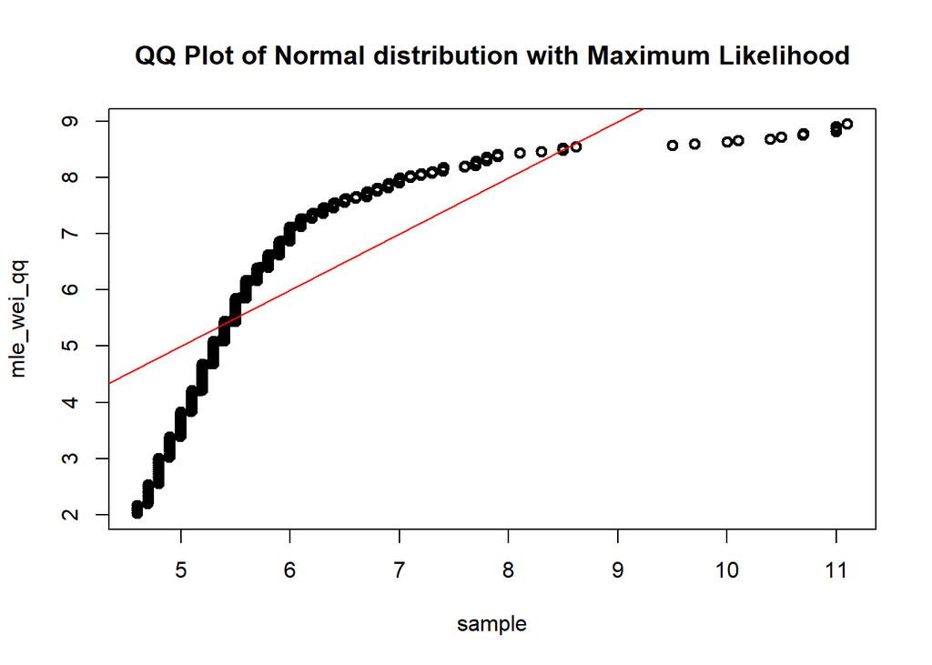

```r
mle_wei_qq<-qweibull(rand,shape=coef(fit_wei)[1],scale=coef(fit_wei)[2])
plot(sample,mle_wei_qq,main="QQ Plot of Normal distribution with Maximum Likelihood",lwd=2)
abline(0,1,col="red",asp=1)
```

This is the qq plot of Weibull distribution under maximum likelihood, and we can see the sample quantile is deviated from the original quantile function at some extent.

## Estimate Median

# Normal Distribution

For the normal distribution, we can use the qnorm combined with the function we created earlier of the maximum likelihood, to retrieve the 50 percentile value which is the estimated median.

```r
qnorm(0.5,mean=coef(fit_norm)[1],sd=coef(fit_norm)[2])
```

```
## [1] 5.7246
```

As we can see, the estimated median under maximum likelihood with Normal distribution is 5.7246.

# Gamma Distribution

For the gamma distribution, we can use the qgamma combined with the function we created earlier of the maximum likelihood, to retrieve the 50 percentile value which is the estimated median.

```r
qgamma(0.5,shape=coef(fit_gamma)[1],scale=coef(fit_gamma)[2])
```

```
## [1] 5.677983
```

As we can see, the estimated median under maximum likelihood with Gamma distribution is 5.677983.

# Weibull Distribution

For the Weibull distribution, we can use qweibull to get the 50 percentile which is the estimated median, so we can just take the 50 percentile of the data and calculate the result.

```r
qweibull(0.5,shape=coef(fit_wei)[1],scale=coef(fit_wei)[2])
```

```
## [1] 5.64902
```

As we can see, the estimated median under maximum likelihood with Weibull distribution is 5.64902.

## Method of Moments (Height)

## Estimates of parameters

For the estimation of parameters, we would take the sampling distribution way to calculate the sample parameters of the distribution that we need.

# Normal Distribution

```r
mm_norm_mean<-mean(d1$ht)
mm_norm_sd<-sd(d1$ht)
mm_norm_mean
```

```
## [1] 160.7419
```

```r
mm_norm_sd
```

```
## [1] 7.320161
```

In the MM method for normal distribution, the estimated mean is 160.7419, and the standard deviation is 7.320161

# Gamma Distribution

```r
mm_gm_shape<-(mean(d1$ht))**2/var(d1$ht)
mm_gm_scale=var(d1$ht)/mean(d1$ht)
mm_gm_shape
```

```
## [1] 482.1886
```

```r
mm_gm_scale
```

```
## [1] 0.333359
```

In the MM method for gamma distribution, the estimated shape is 482.1886, and the scale is 0.333359

# Weibull Distribution

```r
wei_mean<-function(lambda,k){
  lambda*gamma(1+1/k)
}

lambda<-function(mean_bar,k){
  mean_bar/gamma(1+1/k)
}
wei_variance<-function(mean_bar,k,var_bar){
  (lambda(mean_bar,k)^2)*((gamma(1+2/k))-(gamma(1+1/k))^2)-var_bar
}

wei_k<-optimize(function(x){abs(wei_variance(mean_bar=mean(d1$ht),k=x,var_bar = var(d1$ht)))},lower = 0,upper = 50)
wei_k<-wei_k$minimum
wei_lambda<-lambda(mean(d1$ht),wei_k)
wei_k
```

```
## [1] 27.45937
```

```r
wei_lambda
```

```
## [1] 163.9807
```

In the MM method for weibull distribution, we estimated the k as 27.45937 and the lambda as 163.9807

## Overlay estimated pdf onto histogram

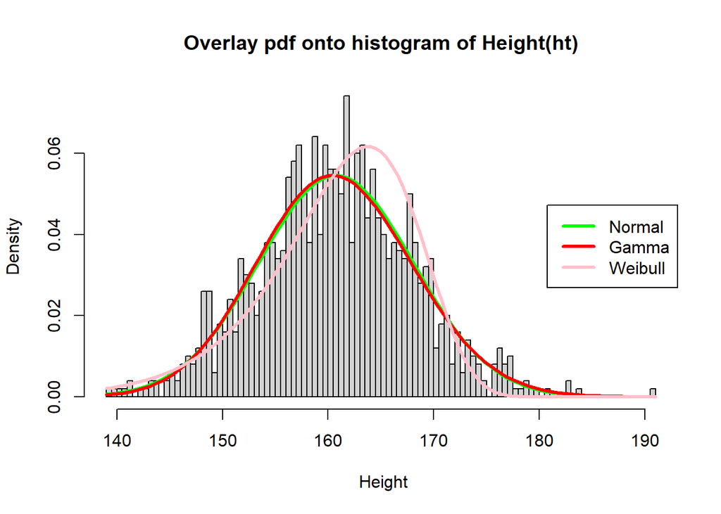

```r
hist(d1$ht,main="Overlay pdf onto histogram of Height(ht)",xlab=" Height",breaks = 100,freq = FALSE)


# Normal Distribution
curve(dnorm(x,mm_norm_mean,mm_norm_sd),add = TRUE,col="green",lwd=3)

# Gamma Distribution
curve(dgamma(x,shape=mm_gm_shape,scale=mm_gm_scale),add=TRUE,col="red",lwd=3)

#Weibull Distribution
curve(dweibull(x,shape=wei_k,scale=wei_lambda),add=TRUE,col="pink",lwd=3)
legend(x="right",legend=c("Normal","Gamma","Weibull"),lty=c(1,1,1),col=c("green","red","pink"),lwd=3)
```

We can see that the original histogram is normally distributed, and the pdf we estimated fits the sampled pdf well for all three distributions except the weibull distribution, which is a little left skewed.

## Overlay estimated CDF onto eCDF

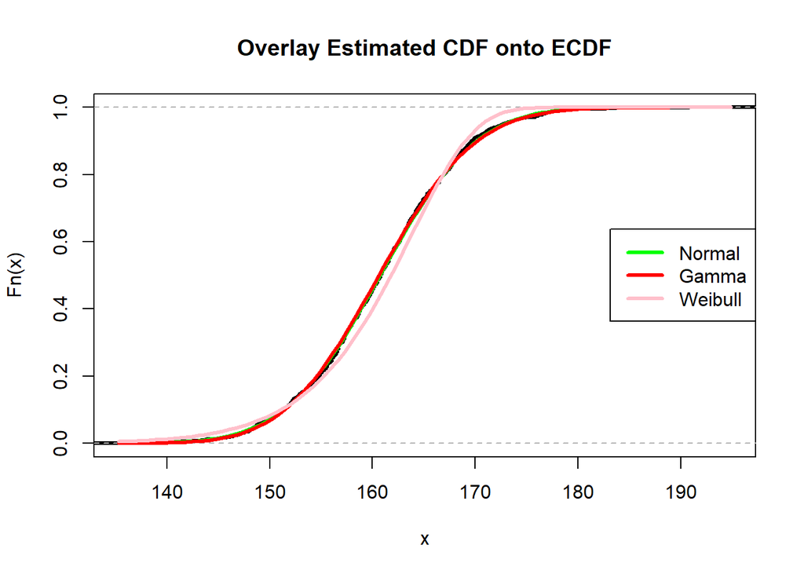

```r
plot(ecdf(d1$ht),do.points=FALSE,lwd=3,main="Overlay Estimated CDF onto ECDF")
# Normal Distribution
curve(pnorm(x,mm_norm_mean,mm_norm_sd),add = TRUE,col="green",lwd=3)

# Gamma Distribution
curve(pgamma(x,shape=mm_gm_shape,scale=mm_gm_scale),add=TRUE,col="red",lwd=3)

#Weibull Distribution
curve(pweibull(x,shape=wei_k,scale=wei_lambda),add=TRUE,col="pink",lwd=3)

legend(x="right",legend=c("Normal","Gamma","Weibull"),lty=c(1,1,1),col=c("green","red","pink"),lwd=3)
```

From the plot, we can see that the estimated CDF of the three distributions are a little deviated from the ECDF of the original data.

## QQ plot(sample vs estimated dist)

For the qqplot, we generate 5000 probability points to get the sample distribution.

```r
sample_p<-ppoints(5000)
y<-quantile(d1$ht,probs = sample_p)
```

# Normal distribution

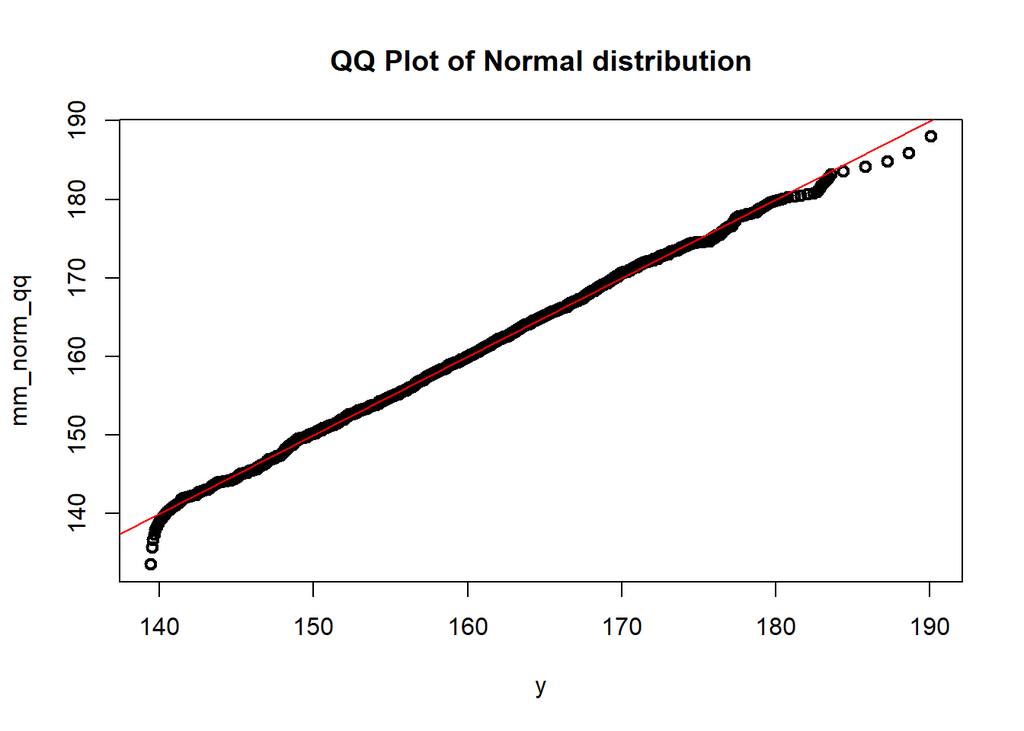

```r
mm_norm_qq<-qnorm(sample_p,mean=mm_norm_mean,sd=mm_norm_sd)
plot(y,mm_norm_qq,main="QQ Plot of Normal distribution",lwd=2)
abline(0,1,col="red")
```

This is the qq plot of normal distribution under method of moments, and we can see the sample quantile fits well with the original quantile.

# Gamma Distribution

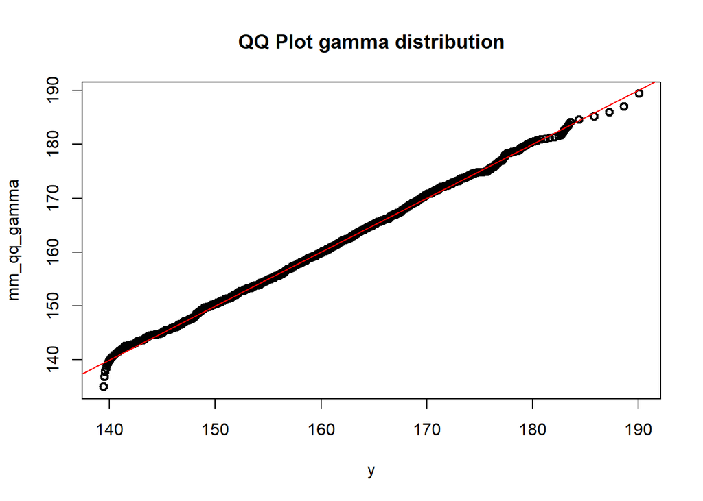

```r
mm_qq_gamma<-qgamma(sample_p,shape=mm_gm_shape,scale=mm_gm_scale)
plot(y,mm_qq_gamma,main="QQ Plot gamma distribution",lwd=2)
abline(a=0,b=1,col="red")
```

This is the qq plot of gamma distribution under method of moments, and we can see the sample quantile fits well with the original quantile.

# Weibull Distribution

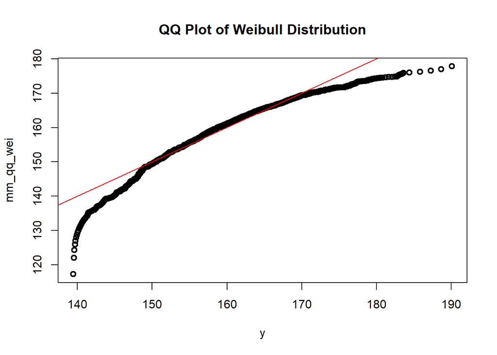

```r
mm_qq_wei<-qweibull(sample_p,shape=wei_k,scale=wei_lambda)
plot(y,mm_qq_wei,main="QQ Plot of Weibull Distribution",lwd=2)
abline(0,1,col="red")
```

This is the qq plot of weibull distribution under method of moments, and we can see the sample quantile is a little deviated from the original quantile.

## Estimate Median

# Normal Distribution

For the normal distribution, the sample median is equal to the population median, so we can just take the median of the data and calculate the result.

```r
median(d1$ht)
```

```
## [1] 160.8
```

As we can see, the estimated median under method of moments with Normal distribution is 160.8.

# Gamma Distribution

For the gamma distribution, we can use qgamma to get the 50 percentile which is the estimated median, so we can just take the 50 percentile of the data and calculate the result.

```r
qgamma(0.5,shape=mm_gm_shape,scale=mm_gm_scale)
```

```
## [1] 160.6308
```

As we can see, the estimated median under method of moments with Gamma distribution is 160.6308.

# Weibull Distribution

For the Weibull distribution, we can use qweibull to get the 50 percentile which is the estimated median, so we can just take the 50 percentile of the data and calculate the result.

```r
qweibull(0.5,shape = wei_k,scale=wei_lambda)
```

```
## [1] 161.8065
```

As we can see, the estimated median under method of moments with Weibull distribution is 161.8065.

## Maximum Likelihood Estimation (Variable: Height(ht))

Now let us take a look at how sampling distribution fits under the maximum likelihood estimation.

## Estimates of parameters

# Normal Distribution

For the estimation of parameters, we would estimate the unknown parameter that maximizes the log likelihood.

```r
require(stats4)
nLL_norm<-function(mean,sd){
  fs<-dnorm(x=d1$ht,mean=mean,sd=sd,log=TRUE)
  -sum(fs)
}
fit_norm<-mle(nLL_norm,start = list(mean=1,sd=1),method="L-BFGS-B",lower = c(0,0.01))
fit_norm
```

```
##
## Call:
## mle(minuslogl = nLL_norm, start = list(mean = 1, sd = 1), method = "L-BFGS-B",
##     lower = c(0, 0.01))
##
## Coefficients:
##       mean         sd
## 160.741901   7.316502
```

For the height in MLE methods with normal distribution, we estimated that the mean as 160.741901, and the sd as 7.316502.

# Gamma Distribution

```r
nLL_gamma<-function(shape,scale){
  fs<-dgamma(x=d1$ht,shape=shape,scale=scale,log=TRUE)
  -sum(fs)
}
fit_gamma<-mle(nLL_gamma,start = list(shape=1,scale=1),method="L-BFGS-B",lower = c(0,0.01))
fit_gamma
```

```
##
## Call:
## mle(minuslogl = nLL_gamma, start = list(shape = 1, scale = 1),
##     method = "L-BFGS-B", lower = c(0, 0.01))
##
## Coefficients:
##       shape       scale
## 479.6460830   0.3351275
```

For the height in MLE methods with gamma distribution, we estimated that the shape as 479.6460830, and the scale as 0.3351275.

# Weibull Distribution

```r
nLL_wei<-function(shape,scale){
  fs<-dweibull(x=d1$ht,shape=shape,scale=scale,log=TRUE)
  -sum(fs)
}
fit_wei<-mle(nLL_wei,start = list(shape=1,scale=1),method="L-BFGS-B",lower = c(0,0.01))
fit_wei
```

```
##
## Call:
## mle(minuslogl = nLL_wei, start = list(shape = 1, scale = 1),
##     method = "L-BFGS-B", lower = c(0, 0.01))
##
## Coefficients:
##     shape     scale
##  21.85398 164.24719
```

For the height in MLE methods with weibull distribution, we estimated that the shape as 21.85398, and the scale as 164.24719 .

## Overlay estimated pdf onto histogram

# Normal Distribution

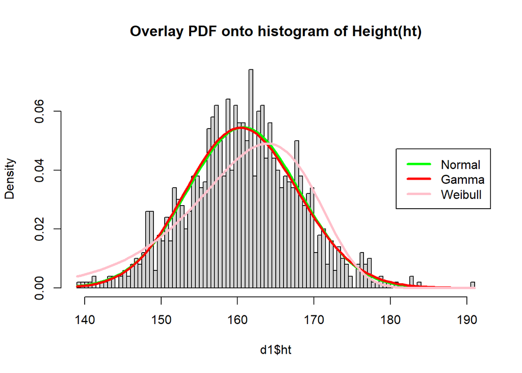

```r
hist(d1$ht,breaks = 100,main="Overlay PDF onto histogram of Height(ht)",freq=FALSE)

#Normal Distribution
curve(dnorm(x,coef(fit_norm)[1],coef(fit_norm)[2]),add=TRUE,col="green",lwd=3)

#Gamma Distribution
curve(dgamma(x,shape=coef(fit_gamma)[1],scale=coef(fit_gamma)[2]),add=TRUE,col="red",lwd=3)

#Weibull Distribution
curve(dweibull(x,shape=coef(fit_wei)[1],scale=coef(fit_wei)[2]),add=TRUE,col="pink",lwd=3)
legend(x="right",legend=c("Normal","Gamma","Weibull"),lty=c(1,1,1),col=c("green","red","pink"),lwd=3)
```

We can see that the original histogram is normally distributed, and the pdf we estimated fits the sampled pdf well for all three distributions except the weibull distribution, which is a little left skewed.

## Overlay estimated CDF onto eCDF

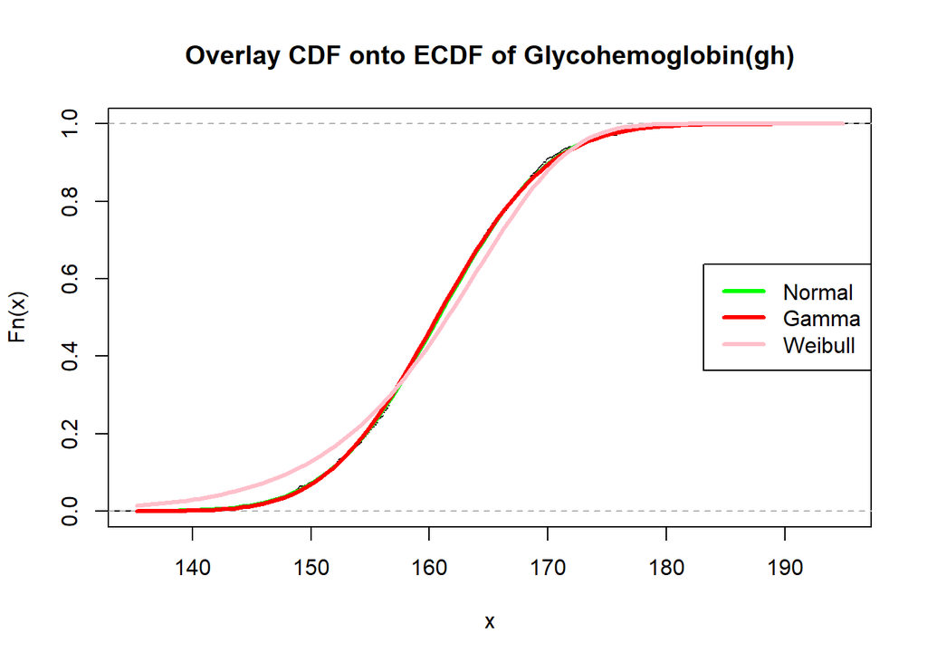

```r
plot(ecdf(d1$ht),main="Overlay CDF onto ECDF of Glycohemoglobin(gh)",do.points=FALSE)

#Normal Distribution
curve(pnorm(x,coef(fit_norm)[1],coef(fit_norm)[2]),add=TRUE,col="green",lwd=3)

#Gamma Distribution
curve(pgamma(x,shape=coef(fit_gamma)[1],scale=coef(fit_gamma)[2]),add=TRUE,col="red",lwd=3)

#Weibull Distribution
curve(pweibull(x,shape=coef(fit_wei)[1],scale=coef(fit_wei)[2]),add=TRUE,col="pink",lwd=3)

legend(x="right",legend=c("Normal","Gamma","Weibull"),lty=c(1,1,1),col=c("green","red","pink"),lwd=3)
```

From the plot, we can see that the estimated CDF of the three distributions are a little deviated from the ECDF of the original data.

## QQ plot(sample vs estimated dist)

```r
# Default
rand<-seq(0.01,0.99,by=0.001)
sample<-quantile(d1$ht,rand)
```

# Normal distribution

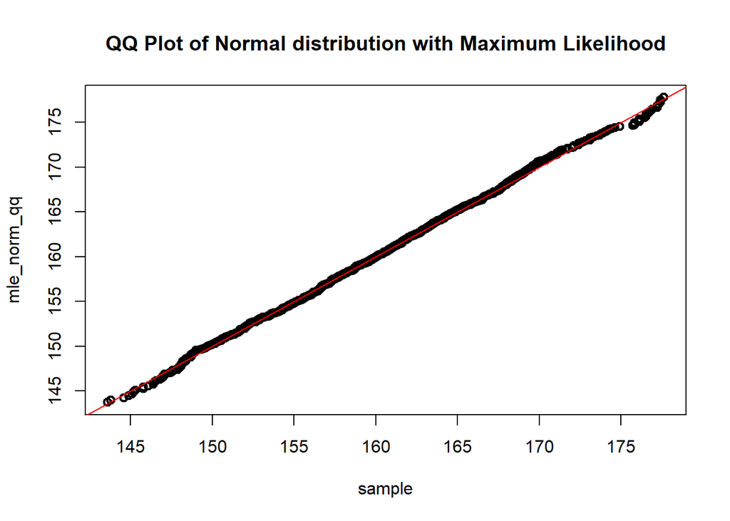

```r
mle_norm_qq<-qnorm(rand,mean=coef(fit_norm)[1],sd=coef(fit_norm)[2])
plot(sample,mle_norm_qq,main="QQ Plot of Normal distribution with Maximum Likelihood",lwd=2)
abline(0,1,col="red",asp=1)
```

This is the qq plot of normal distribution under maximum likelihood, and we can see the sample quantile fits well with the original quantile.

# Gamma Distribution

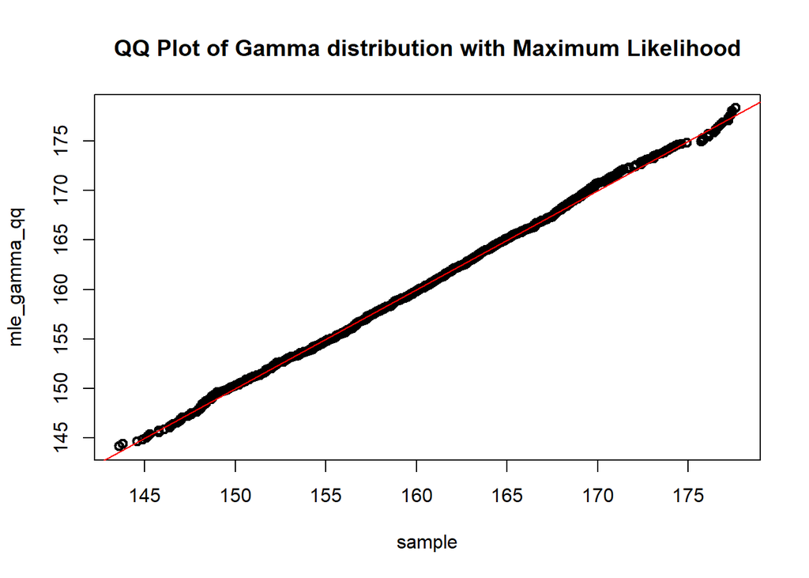

```r
mle_gamma_qq<-qgamma(rand,shape=coef(fit_gamma)[1],scale=coef(fit_gamma)[2])
plot(sample,mle_gamma_qq,main="QQ Plot of Gamma distribution with Maximum Likelihood",lwd=2)
abline(0,1,col="red",asp=1)
```

This is the qq plot of gamma distribution under maximum likelihood, and we can see the sample quantile fits well with the original quantile.

# Weibull Distribution

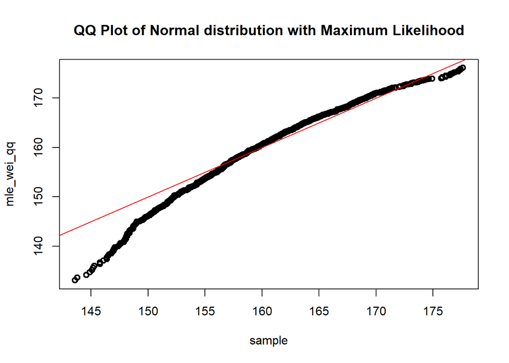

```r
mle_wei_qq<-qweibull(rand,shape=coef(fit_wei)[1],scale=coef(fit_wei)[2])
plot(sample,mle_wei_qq,main="QQ Plot of Normal distribution with Maximum Likelihood",lwd=2)
abline(0,1,col="red",asp=1)
```

This is the qq plot of weibull distribution under maximum likelihood, and we can see the sample quantile fits large percent of the original quantile.

## Estimate Median

# Normal Distribution

For the normal distribution, we can use the qnorm combined with the function we created earlier of the maximum likelihood, to retrieve the 50 percentile value which is the estimated median.

```r
qnorm(0.5,mean=coef(fit_norm)[1],sd=coef(fit_norm)[2])
```

```
## [1] 160.7419
```

As we can see, the estimated median under maximum likelihood with Normal distribution is 160.7419.

# Gamma Distribution

For the gamma distribution, we can use the qgamma combined with the function we created earlier of the maximum likelihood, to retrieve the 50 percentile value which is the estimated median.

```r
qgamma(0.5,shape=coef(fit_gamma)[1],scale=coef(fit_gamma)[2])
```

```
## [1] 160.6309
```

As we can see, the estimated median under maximum likelihood with Gamma distribution is 160.6309.

# Weibull Distribution

For the Weibull distribution, we can use qweibull to get the 50 percentile which is the estimated median, so we can just take the 50 percentile of the data and calculate the result.

```r
qweibull(0.5,shape=coef(fit_wei)[1],scale=coef(fit_wei)[2])
```

```
## [1] 161.5156
```

As we can see, the estimated median under maximum likelihood with Weibull distribution is 161.5156.